# Předmět: Bayesiánská analýza (MPE_BAAN)

Třetí úkol (skupina 13)

2026-07-14

# PŘÍKLAD 4

# Exercise 14.11 (Open exercise: vaccine safety)

> The *pulse_of_the_nation* survey also asked respondents about their agreement with the statement that *vaccines_are_safe*, selecting from the following options: *Neither Agree nor Disagree*, *Somewhat Agree*, *Somewhat Disagree*, *Strongly Agree* or *Strongly Disagree*. In this open-ended exercise, we complete a naive Bayesian analysis of belief in the safety of vaccines, selecting a variety of possible predictors.

## Úvod a cíl analýzy

Cílem této úlohy je aplikovat **naivní Bayesovský klasifikátor** (kapitola 14 učebnice *Bayes Rules!*) na data z průzkumu *Pulse of the Nation* a analyzovat, jak politické, demografické a socioekonomické charakteristiky respondentů souvisí s jejich postojem k výroku **„Vaccines are safe”**.

Odezvová proměnná má pět kategorií (Likertova škála), a je proto vhodná pro vícetřídní klasifikaci pomocí naivního Bayese.

## Použitá data a proměnné

**Odezvová proměnná:**

- `vaccines_are_safe` – míra souhlasu s tvrzením, že vakcíny jsou bezpečné

**Prediktory:**

- `age` – věk respondenta
- `income` – příjem domácnosti
- `education` – dosažené vzdělání
- `party` – stranická identifikace
- `trump_approval` – hodnocení Donalda Trumpa
- `robots` – postoj k robotizaci (proxy vztahu k technologiím a vědě)

Zvolené proměnné reprezentují kombinaci politických postojů a socioekonomických charakteristik, které mohou souviset s důvěrou ve vědu a zdravotní doporučení.

## Příprava dat

```r
# Načtení dat
data(pulse_of_the_nation)

# Výběr proměnných a odstranění chybějících hodnot
potn <- pulse_of_the_nation %>%
  select(
    vaccines_are_safe,
    age,
    income,
    education,
    party,
    trump_approval,
    robots
  ) %>%
  drop_na()

# Základní přehled
dim(potn)
```

```
## [1] 1000    7
```

Po odstranění chybějících hodnot máme k dispozici 1000 kompletních pozorování.

## Explorativní analýza

### Rozdělení odpovědí

Nejprve se podíváme na rozdělení odpovědí na otázku týkající se bezpečnosti vakcín.

```r
potn %>% tabyl(vaccines_are_safe) %>%
  adorn_pct_formatting(digits = 1)
```

```
##           vaccines_are_safe   n percent
##  Neither Agree nor Disagree  16    1.6%
##              Somewhat Agree 206   20.6%
##           Somewhat Disagree  76    7.6%
##              Strongly Agree 642   64.2%
##           Strongly Disagree  60    6.0%
```

### Grafické znázornění rozdělení odpovědí

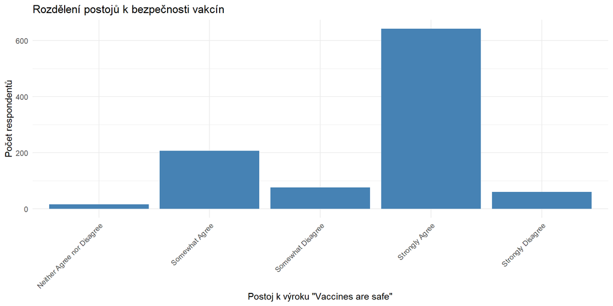

```r
ggplot(potn, aes(x = vaccines_are_safe)) +
  geom_bar(fill = "steelblue") +
  labs(
    title = "Rozdělení postojů k bezpečnosti vakcín",
    x = "Postoj k výroku \"Vaccines are safe\"",
    y = "Počet respondentů"
  ) +
  theme_minimal() +
  theme(axis.text.x = element_text(angle = 45, hjust = 1))
```

**Interpretace:** Rozdělení odpovědí je výrazně nevyvážené – dominuje kategorie *Strongly Agree* (přibližně 64% respondentů), zatímco neutrální a nesouhlasné odpovědi jsou zastoupeny jen v malém počtu případů. Tato nevyváženost má důležité důsledky pro chování klasifikačního modelu.

### Vizualizace vztahů s prediktory

Podle postupu z učebnice (kapitola 14, Figures 14.1 a 14.2 pro penguins) si nejprve vizualizujeme vztahy mezi odezvovou proměnnou a vybranými prediktory.

#### Vztah s politickou stranou

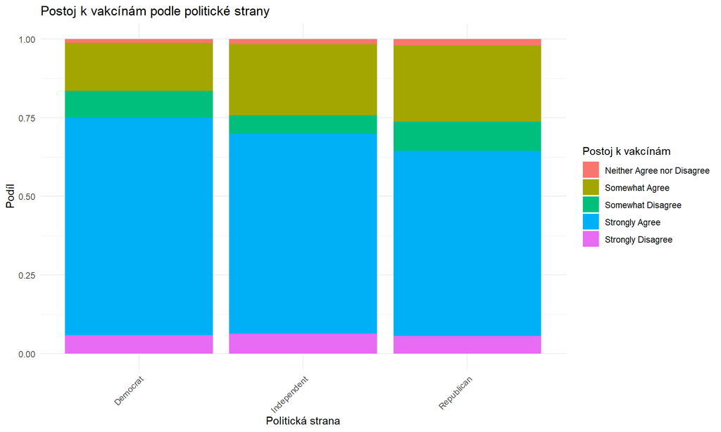

```r
# Proporcionální sloupcový graf (jako Figure 14.1 v učebnici)
ggplot(potn %>% drop_na(party, vaccines_are_safe),
       aes(x = party, fill = vaccines_are_safe)) +
  geom_bar(position = "fill") +
  labs(
    title = "Postoj k vakcínám podle politické strany",
    x = "Politická strana",
    y = "Podíl",
    fill = "Postoj k vakcínám"
  ) +
  theme_minimal() +
  theme(axis.text.x = element_text(angle = 45, hjust = 1))
```

**Interpretace:** Graf ukazuje rozdíly v postojích k vakcínám mezi politickými stranami. Každý sloupec má výšku 1 (100 %), a barevné části ukazují podíl respondentů s různými názory.

#### Vztah s hodnocením Trumpa

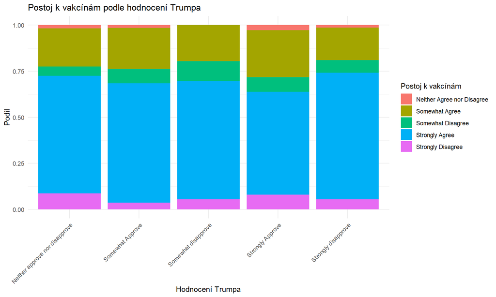

```r
ggplot(potn %>% drop_na(trump_approval, vaccines_are_safe),
       aes(x = trump_approval, fill = vaccines_are_safe)) +
  geom_bar(position = "fill") +
  labs(
    title = "Postoj k vakcínám podle hodnocení Trumpa",
    x = "Hodnocení Trumpa",
    y = "Podíl",
    fill = "Postoj k vakcínám"
  ) +
  theme_minimal() +
  theme(axis.text.x = element_text(angle = 45, hjust = 1))
```

#### Vztah s věkem (kvantitativní prediktor)

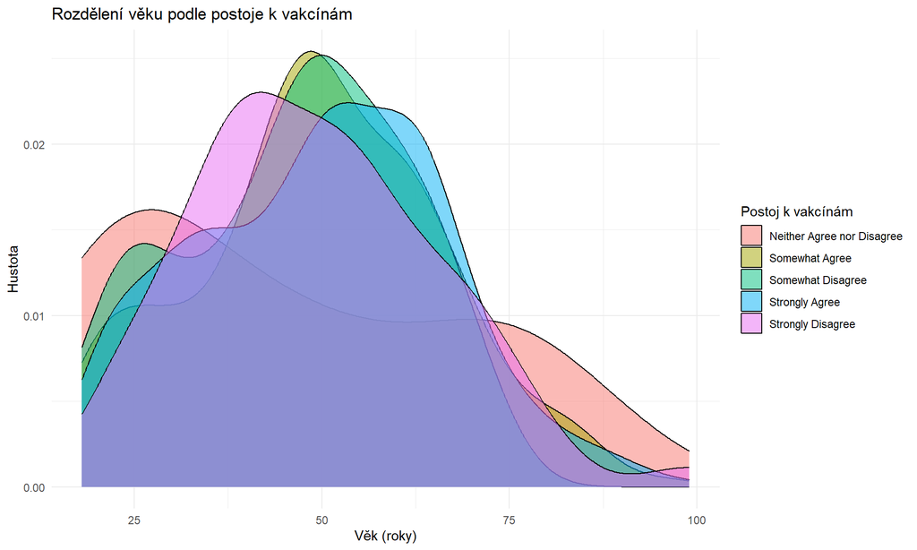

```r
# Density plot (jako Figure 14.2 v učebnici)
ggplot(potn %>% drop_na(age, vaccines_are_safe),
       aes(x = age, fill = vaccines_are_safe)) +
  geom_density(alpha = 0.5) +
  labs(
    title = "Rozdělení věku podle postoje k vakcínám",
    x = "Věk (roky)",
    y = "Hustota",
    fill = "Postoj k vakcínám"
  ) +
  theme_minimal()
```

**Interpretace:** Každá barevná křivka ukazuje, jak jsou rozloženi lidé daného věku v rámci každé kategorie názoru. Pokud se křivky hodně překrývají, věk pravděpodobně nebude silným prediktorem.

#### Vztah s příjmem (kvantitativní prediktor)

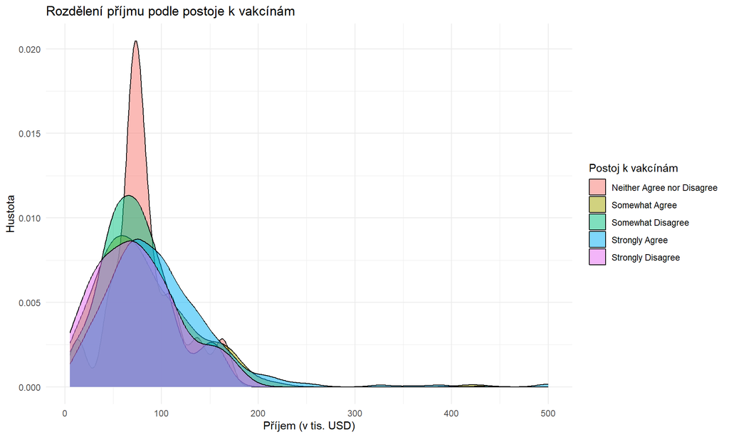

```r
ggplot(potn %>% drop_na(income, vaccines_are_safe),
       aes(x = income, fill = vaccines_are_safe)) +
  geom_density(alpha = 0.5) +
  labs(
    title = "Rozdělení příjmu podle postoje k vakcínám",
    x = "Příjem (v tis. USD)",
    y = "Hustota",
    fill = "Postoj k vakcínám"
  ) +
  theme_minimal()
```

### Normální rozdělení kvantitativních prediktorů

Naivní Bayesovský model předpokládá, že kvantitativní prediktory (jako věk a příjem) mají **normální rozdělení** v rámci každé kategorie odezvové proměnné (viz Section 14.1.2 v učebnici). To znamená, že pro každou kategorii `vaccines_are_safe` model odhaduje střední hodnotu $\mu$ a směrodajnou odchylku $\sigma$.

#### Normální rozdělení pro věk

```r
# Výpočet průměru a směrodajné odchylky věku pro každou kategorii
age_stats <- potn %>%
  group_by(vaccines_are_safe) %>%
  summarize(
    mean_age = mean(age, na.rm = TRUE),
    sd_age = sd(age, na.rm = TRUE),
    n = n(),
    .groups = "drop"
  ) %>%
  arrange(desc(n))

age_stats
```

```
## # A tibble: 5 × 4
##   vaccines_are_safe          mean_age sd_age     n
##   <fct>                         <dbl>  <dbl> <int>
## 1 Strongly Agree                 49.9   16.7   642
## 2 Somewhat Agree                 49.5   16.5   206
## 3 Somewhat Disagree              46.4   14.8    76
## 4 Strongly Disagree              49.2   16.2    60
## 5 Neither Agree nor Disagree     45.3   23.3    16
```

**Interpretace:** Model předpokládá, že například lidé, kteří odpověděli “Strongly Agree”, mají věk normálně rozložený okolo průměru 49.9 roků se směrodajnou odchylkou 16.7 roků.

#### Normální rozdělení pro příjem

```r
# Výpočet průměru a směrodajné odchylky příjmu pro každou kategorii
income_stats <- potn %>%
  group_by(vaccines_are_safe) %>%
  summarize(
    mean_income = mean(income, na.rm = TRUE),
    sd_income = sd(income, na.rm = TRUE),
    n = n(),
    .groups = "drop"
  ) %>%
  arrange(desc(n))

income_stats
```

```
## # A tibble: 5 × 4
##   vaccines_are_safe          mean_income sd_income     n
##   <fct>                            <dbl>     <dbl> <int>
## 1 Strongly Agree                    96.8      60.2   642
## 2 Somewhat Agree                    82.1      51.8   206
## 3 Somewhat Disagree                 74.2      36.5    76
## 4 Strongly Disagree                 74.6      42.9    60
## 5 Neither Agree nor Disagree        81.7      35.6    16
```

## Naivní Bayesovské modely

### Model 1: Pouze politické proměnné

Nejprve odhadneme zjednodušený model, který využívá pouze politické charakteristiky respondentů.

```r
nb_model_1 <- naiveBayes(
  vaccines_are_safe ~ party + trump_approval,
  data = potn
)

# Zobrazení modelu
nb_model_1
```

```
##
## Naive Bayes Classifier for Discrete Predictors
##
## Call:
## naiveBayes.default(x = X, y = Y, laplace = laplace)
##
## A-priori probabilities:
## Y
## Neither Agree nor Disagree             Somewhat Agree
##                      0.016                      0.206
##          Somewhat Disagree             Strongly Agree
##                      0.076                      0.642
##          Strongly Disagree
##                      0.060
##
## Conditional probabilities:
##                             party
## Y                             Democrat Independent Republican
##   Neither Agree nor Disagree 0.2500000   0.4375000  0.3125000
##   Somewhat Agree             0.2427184   0.4660194  0.2912621
##   Somewhat Disagree          0.3684211   0.3289474  0.3026316
##   Strongly Agree             0.3520249   0.4205607  0.2274143
##   Strongly Disagree          0.3166667   0.4500000  0.2333333
##
##                             trump_approval
## Y                            Neither approve nor disapprove Somewhat Approve
##   Neither Agree nor Disagree                     0.06250000       0.12500000
##   Somewhat Agree                                 0.05825243       0.15048544
##   Somewhat Disagree                              0.03947368       0.14473684
##   Strongly Agree                                 0.05763240       0.14018692
##   Strongly Disagree                              0.08333333       0.08333333
##                             trump_approval
## Y                            Somewhat disapprove Strongly Approve
##   Neither Agree nor Disagree          0.00000000       0.43750000
##   Somewhat Agree                      0.08737864       0.31067961
##   Somewhat Disagree                   0.13157895       0.26315789
##   Strongly Agree                      0.09190031       0.21806854
##   Strongly Disagree                   0.08333333       0.33333333
##                             trump_approval
## Y                            Strongly disapprove
##   Neither Agree nor Disagree          0.37500000
##   Somewhat Agree                      0.39320388
##   Somewhat Disagree                   0.42105263
##   Strongly Agree                      0.49221184
##   Strongly Disagree                   0.41666667
```

**Co model obsahuje:**

- **A-priori pravděpodobnosti** jednotlivých kategorií (odhadnuté z dat)
- **Podmíněné pravděpodobnosti** pro kategorické prediktory (proporce)

### Model 2: Rozšířený model

Hlavním modelem analýzy je rozšířený naivní Bayesovský model, který kombinuje politické, demografické a socioekonomické prediktory.

```r
nb_model_2 <- naiveBayes(
  vaccines_are_safe ~ age + income + education +
    party + trump_approval + robots,
  data = potn
)

# Zobrazení modelu
nb_model_2
```

```
##
## Naive Bayes Classifier for Discrete Predictors
##
## Call:
## naiveBayes.default(x = X, y = Y, laplace = laplace)
##
## A-priori probabilities:
## Y
## Neither Agree nor Disagree             Somewhat Agree
##                      0.016                      0.206
##          Somewhat Disagree             Strongly Agree
##                      0.076                      0.642
##          Strongly Disagree
##                      0.060
##
## Conditional probabilities:
##                             age
## Y                                [,1]     [,2]
##   Neither Agree nor Disagree 45.31250 23.25430
##   Somewhat Agree             49.49029 16.47637
##   Somewhat Disagree          46.40789 14.76137
##   Strongly Agree             49.85826 16.73871
##   Strongly Disagree          49.20000 16.18202
##
##                             income
## Y                                [,1]     [,2]
##   Neither Agree nor Disagree 81.68750 35.58224
##   Somewhat Agree             82.08738 51.84444
##   Somewhat Disagree          74.21053 36.53649
##   Strongly Agree             96.77570 60.21412
##   Strongly Disagree          74.63333 42.94023
##
##                             education
## Y                            College degree Graduate degree High school
##   Neither Agree nor Disagree     0.31250000      0.25000000  0.00000000
##   Somewhat Agree                 0.33495146      0.15048544  0.19417476
##   Somewhat Disagree              0.18421053      0.22368421  0.25000000
##   Strongly Agree                 0.31775701      0.21962617  0.18224299
##   Strongly Disagree              0.35000000      0.16666667  0.25000000
##                             education
```

[output cut: 29 more lines]

```
##                             trump_approval
## Y                            Strongly disapprove
##   Neither Agree nor Disagree          0.37500000
##   Somewhat Agree                      0.39320388
##   Somewhat Disagree                   0.42105263
##   Strongly Agree                      0.49221184
##   Strongly Disagree                   0.41666667
##
##                             robots
## Y                               Likely  Unlikely
##   Neither Agree nor Disagree 0.3125000 0.6875000
##   Somewhat Agree             0.2766990 0.7233010
##   Somewhat Disagree          0.1842105 0.8157895
##   Strongly Agree             0.1604361 0.8395639
##   Strongly Disagree          0.3333333 0.6666667
```

**Co model obsahuje:**

- **A-priori pravděpodobnosti** kategorií
- **Podmíněné pravděpodobnosti** pro kategorické prediktory
- **Parametry normálního rozdělení** (střední hodnota a směrodajná odchylka) pro kvantitativní prediktory `age` a `income`

## Predikce na konkrétních příkladech

Podle postupu z učebnice (Section 14.1.3) otestujeme model na konkrétních hypotetických respondentech.

### Příklad 1: Mladý vzdělaný demokrat

```r
# Profil: mladý člověk s vysokoškolským vzděláním, demokrat, nesouhlasí s Trumpem
test_person_1 <- data.frame(
  age = 28,
  income = 80,
  education = "Graduate Degree",
  party = "Democrat",
  trump_approval = "Strongly Disapprove",
  robots = "Very likely"
)

# Posteriorní pravděpodobnosti jednotlivých kategorií
pred_1_raw <- predict(nb_model_2, newdata = test_person_1, type = "raw")
pred_1_class <- predict(nb_model_2, newdata = test_person_1)

pred_1_raw
```

```
##      Neither Agree nor Disagree Somewhat Agree Somewhat Disagree Strongly Agree
## [1,]                 0.02351383      0.1605027         0.1513608      0.5907289
##      Strongly Disagree
## [1,]        0.07389377
```

**Klasifikace:** Model klasifikuje tuto osobu jako **Strongly Agree** s posteriorní pravděpodobností 59.1%.

### Příklad 2: Starší republikán

```r
# Profil: starší člověk, nižší vzdělání, republikán, souhlasí s Trumpem
test_person_2 <- data.frame(
  age = 65,
  income = 45,
  education = "High School Degree",
  party = "Republican",
  trump_approval = "Strongly Approve",
  robots = "Not likely at all"
)

# Posteriorní pravděpodobnosti
pred_2_raw <- predict(nb_model_2, newdata = test_person_2, type = "raw")
pred_2_class <- predict(nb_model_2, newdata = test_person_2)

pred_2_raw
```

```
##      Neither Agree nor Disagree Somewhat Agree Somewhat Disagree Strongly Agree
## [1,]                  0.0325014      0.3247454         0.1104076      0.4339766
##      Strongly Disagree
## [1,]        0.09836906
```

**Klasifikace:** Model klasifikuje tuto osobu jako **Strongly Agree** s posteriorní pravděpodobností 43.4%.

### Příklad 3: Středně starý nezávislý

```r
# Profil: středně starý nezávislý, neutrální postoje
test_person_3 <- data.frame(
  age = 45,
  income = 60,
  education = "Some College",
  party = "Independent",
  trump_approval = "Neither Approve nor Disapprove",
  robots = "Somewhat likely"
)

# Posteriorní pravděpodobnosti
pred_3_raw <- predict(nb_model_2, newdata = test_person_3, type = "raw")
pred_3_class <- predict(nb_model_2, newdata = test_person_3)

pred_3_raw
```

```
##      Neither Agree nor Disagree Somewhat Agree Somewhat Disagree Strongly Agree
## [1,]                 0.01768282       0.248923         0.1076863      0.5364762
##      Strongly Disagree
## [1,]        0.08923165
```

**Klasifikace:** Model klasifikuje tuto osobu jako **Strongly Agree** s posteriorní pravděpodobností 53.6%.

## Vyhodnocení modelů

### Konfuzní matice pro oba modely

#### Model 1: Pouze politické proměnné

```r
# Přidání predikcí do datasetu
potn <- potn %>%
  mutate(pred_model_1 = predict(nb_model_1, newdata = .))

# Konfuzní matice
conf_mat_1 <- potn %>%
  tabyl(vaccines_are_safe, pred_model_1) %>%
  adorn_percentages("row") %>%
  adorn_pct_formatting(digits = 2) %>%
  adorn_ns()

conf_mat_1
```

```
##           vaccines_are_safe Neither Agree nor Disagree Somewhat Agree
##  Neither Agree nor Disagree                  0.00% (0)      0.00% (0)
##              Somewhat Agree                  0.00% (0)      0.00% (0)
##           Somewhat Disagree                  0.00% (0)      0.00% (0)
##              Strongly Agree                  0.00% (0)      0.00% (0)
##           Strongly Disagree                  0.00% (0)      0.00% (0)
##  Somewhat Disagree Strongly Agree Strongly Disagree
##          0.00% (0)  100.00%  (16)         0.00% (0)
##          0.00% (0)  100.00% (206)         0.00% (0)
##          0.00% (0)  100.00%  (76)         0.00% (0)
##          0.00% (0)  100.00% (642)         0.00% (0)
##          0.00% (0)  100.00%  (60)         0.00% (0)
```

#### Model 2: Rozšířený model

```r
# Přidání predikcí
potn <- potn %>%
  mutate(pred_model_2 = predict(nb_model_2, newdata = .))

# Konfuzní matice
conf_mat_2 <- potn %>%
  tabyl(vaccines_are_safe, pred_model_2) %>%
  adorn_percentages("row") %>%
  adorn_pct_formatting(digits = 2) %>%
  adorn_ns()

conf_mat_2
```

```
##           vaccines_are_safe Neither Agree nor Disagree Somewhat Agree
##  Neither Agree nor Disagree                  0.00% (0)     0.00%  (0)
##              Somewhat Agree                  0.00% (0)     5.34% (11)
##           Somewhat Disagree                  0.00% (0)     7.89%  (6)
##              Strongly Agree                  0.00% (0)     2.65% (17)
##           Strongly Disagree                  0.00% (0)    11.67%  (7)
##  Somewhat Disagree Strongly Agree Strongly Disagree
##          0.00% (0)  100.00%  (16)         0.00% (0)
##          0.00% (0)   94.66% (195)         0.00% (0)
##          0.00% (0)   92.11%  (70)         0.00% (0)
##          0.00% (0)   97.35% (625)         0.00% (0)
##          0.00% (0)   88.33%  (53)         0.00% (0)
```

**Interpretace:** Model má tendenci predikovat především nejčetnější kategorie *Strongly Agree* a *Somewhat Agree*. Méně zastoupené kategorie (zejména neutrální a nesouhlasné odpovědi) nejsou téměř nikdy správně klasifikovány. Tento výsledek je v souladu s výraznou nevyvážeností dat.

### Porovnání přesnosti modelů

```r
# Celková přesnost Model 1
accuracy_1 <- potn %>%
  filter(!is.na(vaccines_are_safe) & !is.na(pred_model_1)) %>%
  summarize(accuracy = mean(vaccines_are_safe == pred_model_1)) %>%
  pull(accuracy)

# Celková přesnost Model 2
accuracy_2 <- potn %>%
  filter(!is.na(vaccines_are_safe) & !is.na(pred_model_2)) %>%
  summarize(accuracy = mean(vaccines_are_safe == pred_model_2)) %>%
  pull(accuracy)
```

**Celková přesnost:**

- **Model 1** (pouze politické proměnné): 64.2%
- **Model 2** (rozšířený model): 63.6%

## Křížová validace

Pro posouzení generalizační schopnosti modelu použijeme 10násobnou křížovou validaci dle postupu uvedeného v kapitole 14 učebnice.

```r
set.seed(84735)

cv_results <- naive_classification_summary_cv(
  model = nb_model_2,
  data = potn,
  y = "vaccines_are_safe",
  k = 10
)

cv_results$cv
```

```
##           vaccines_are_safe Neither Agree nor Disagree Somewhat Agree
##  Neither Agree nor Disagree                  0.00% (0)     0.00%  (0)
##              Somewhat Agree                  0.00% (0)     3.40%  (7)
##           Somewhat Disagree                  0.00% (0)     3.95%  (3)
##              Strongly Agree                  0.00% (0)     3.43% (22)
##           Strongly Disagree                  0.00% (0)    11.67%  (7)
##  Somewhat Disagree Strongly Agree Strongly Disagree
##          0.00% (0)  100.00%  (16)         0.00% (0)
##          0.00% (0)   96.60% (199)         0.00% (0)
##          0.00% (0)   96.05%  (73)         0.00% (0)
##          0.00% (0)   96.57% (620)         0.00% (0)
##          0.00% (0)   88.33%  (53)         0.00% (0)
```

**Interpretace:** Výsledky křížové validace jsou velmi podobné konfuzní matici vypočtené na celém vzorku. To naznačuje, že chování modelu není způsobeno přeučením, ale odráží skutečnou strukturu dat a dominanci jedné odpovědní kategorie.

## Závěr

Naivní Bayesovský klasifikátor se ukázal jako vhodný nástroj pro vícetřídní analýzu postojů k bezpečnosti vakcín. Výsledky analýzy ukazují, že model je schopen velmi stabilně identifikovat dominantní souhlasné postoje, zejména kategorii Strongly Agree, která tvoří převážnou část datového souboru.

**Hlavní zjištění:**

Přestože rozšířený model využívající politické, demografické i socioekonomické proměnné poskytuje konzistentní výsledky napříč validačními postupy, jeho prediktivní schopnost je do značné míry tažena právě dominancí jedné odpovědní kategorie. Analýza tak názorně demonstruje nejen praktickou aplikaci naivního Bayesovského přístupu na reálných sociálních datech, ale také důležitost kritického zohlednění struktury dat při interpretaci výsledků klasifikačních modelů.

**Možná vylepšení:**

- Využití technik pro práci s nevyváženými daty (např. převzorkování menšinových tříd)
- Zkoušení alternativních klasifikačních metod, které lépe zvládají nevyvážené třídy
- Agregace některých méně četných kategorií pro zjednodušení klasifikačního problému